# [DATA1] Flux aériens entre les villes du Monde en 2014

Masters Géoprisme et Carthageo

Author

Claude Grasland

Published

September 1, 2025

```r
library(sf)
library(dplyr)
library(mapsf)
```

## 1 Introduction

Le jeu de données présenté ici a été constitué par les membres du projet openflight étudier les relations aériennes entre les villes du Monde en 2014

La base a été harmonisée par C. Grasland dans le cadre d’un cours de L3 Géographie Structures du Monde Actuel. L’harmonisation concerne notamment l’agrégation des aéroports d’une même ville et le codage commun des deux sources.

Les données décrites peuvent être récupérées [dans ce dossier sur gihub](https://github.com/worldregio/anspa/tree/main/openflight)

## 2 Le fichier **cities.RDS**

### 2.1 Chargement du fichier

Il s’agit d’un fichier sf qu’il faut donc ouvrir après avoir chargé ce package.

```r
library(sf)
cities <- readRDS("openflight/cities.RDS")
states <- readRDS("openflight/states.RDS")
dim(cities)
```

```
[1] 3113   19
```

```r
head(cities)
```

```
Simple feature collection with 6 features and 18 fields
Geometry type: POINT
Dimension:     XY
Bounding box:  xmin: -0.186414 ymin: 27.8376 xmax: 69.2123 ymax: 41.4147
CRS:           NA
      Country           City ID_ref                                Airport_ref
1 Afghanistan          Herat   2048                              Herat Airport
2 Afghanistan          Kabul   2050         Hamid Karzai International Airport
3 Afghanistan       Kandahar   2051                           Kandahar Airport
4 Afghanistan Mazar-i-sharif   2053                     Mazar I Sharif Airport
5     Albania         Tirana   1190 Tirana International Airport Mother Teresa
6     Algeria          Adrar    234 Touat Cheikh Sidi Mohamed Belkebir Airport
  VN_i      DN_i VN_j      DN_j VI_i      DI_i VI_j      DI_j VN VI  V
1    1  643.3509    1  643.3509    3  2877.408    3  2877.408  2  6  8
2    3 1404.7085    3 1404.7085   11 17006.790    9 13319.382  6 20 26
3    1  462.4930    1  462.4930    3  3148.567    3  3148.567  2  6  8
4    1  298.8646    1  298.8646    2  4791.803    2  4019.950  2  4  6
5    0    0.0000    0    0.0000   17 14936.143   17 14936.143  0 34 34
6    6 4735.1352    5 4460.7992    0     0.000    0     0.000 11  0 11
         DN        DI         D                  geometry
1 1286.7018  5754.815  7041.517     POINT (62.2283 34.21)
2 2809.4169 30326.173 33135.590   POINT (69.2123 34.5659)
3  924.9860  6297.134  7222.120   POINT (65.8478 31.5058)
4  597.7292  8811.753  9409.482   POINT (67.2097 36.7069)
5    0.0000 29872.286 29872.286   POINT (19.7206 41.4147)
6 9195.9344     0.000  9195.934 POINT (-0.186414 27.8376)
```

On note pour chaque ville le nombre de vols (V) selon qu’ils sont nationaux (VN) ou de internationaux (VI) ainsi que la somme des distances (D) intranationales (DN) ou internationales (DI) parcourues par ces vols.

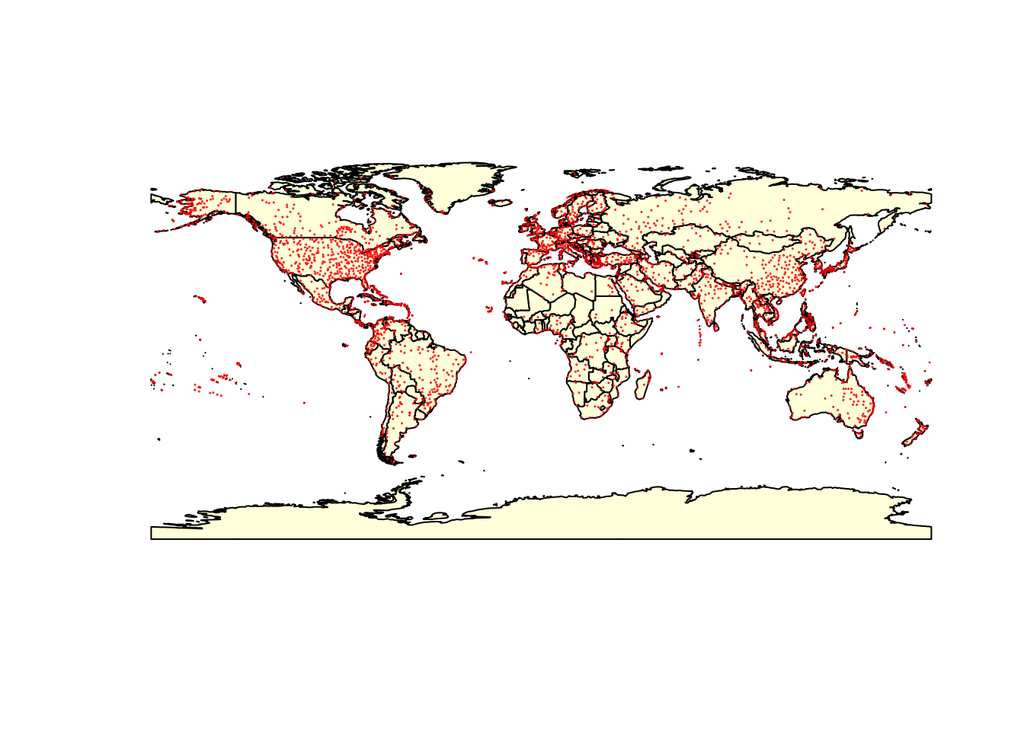

```r
plot(states$geometry,col="lightyellow")
plot(cities$geometry, col="red",cex=0.1, pch=20, add=T)
```

Comme on peut le voir, la base offre uune très large couverture du Monde avec une grande finesse de détail.

## 3 Le fichier **cities_links.RDS**

### 3.1 Chargement du fichier

Il s’agit d’un fichier sf qu’il faut donc ouvrir après avoir chargé ce package.

```r
library(sf)
links <- readRDS("openflight/cities_links.RDS")
states <- readRDS("openflight/states.RDS")
dim(links)
```

```
[1] 34036    14
```

```r
head(links)
```

```
Simple feature collection with 6 features and 13 fields
Geometry type: LINESTRING
Dimension:     XY
Bounding box:  xmin: 55.46237 ymin: 25.31841 xmax: 69.19299 ymax: 36.68587
Geodetic CRS:  WGS 84
        Sta_j                Sta_i    i    j          Cit_i   Lon_i   Lat_i
1 Afghanistan          Afghanistan 2050 2048          Kabul 69.2123 34.5659
2 Afghanistan United Arab Emirates 2188 2051          Dubai 55.3644 25.2528
3 Afghanistan          Afghanistan 2053 2050 Mazar-i-sharif 67.2097 36.7069
4 Afghanistan          Afghanistan 2050 2053          Kabul 69.2123 34.5659
5 Afghanistan          Afghanistan 2048 2050          Herat 62.2283 34.2100
6 Afghanistan          Afghanistan 2051 2050       Kandahar 65.8478 31.5058
           Cit_j   Lon_j   Lat_j       Dij Sta_iso3_i Sta_iso3_j
1          Herat 62.2283 34.2100  643.3509        AFG        AFG
2       Kandahar 65.8478 31.5058 1238.3196        ARE        AFG
3          Kabul 69.2123 34.5659  298.8646        AFG        AFG
4 Mazar-i-sharif 67.2097 36.7069  298.8646        AFG        AFG
5          Kabul 69.2123 34.5659  643.3509        AFG        AFG
6          Kabul 69.2123 34.5659  462.4930        AFG        AFG
                        geometry
1 LINESTRING (69.14292 34.564...
2 LINESTRING (55.46237 25.318...
3 LINESTRING (67.23007 36.685...
4 LINESTRING (69.19299 34.587...
5 LINESTRING (62.2971 34.2154...
6 LINESTRING (65.88 31.53653,...
```

La base comporte 34036 liens correspondant à des vols directs.

### 3.2 Visualisation des liens

La géométrie associée permet de tracer les vols en suivant le plus court chemin à vol d’oiseau. Essayons par exemple de tracer le lien Paris-Tokyo en 2014.

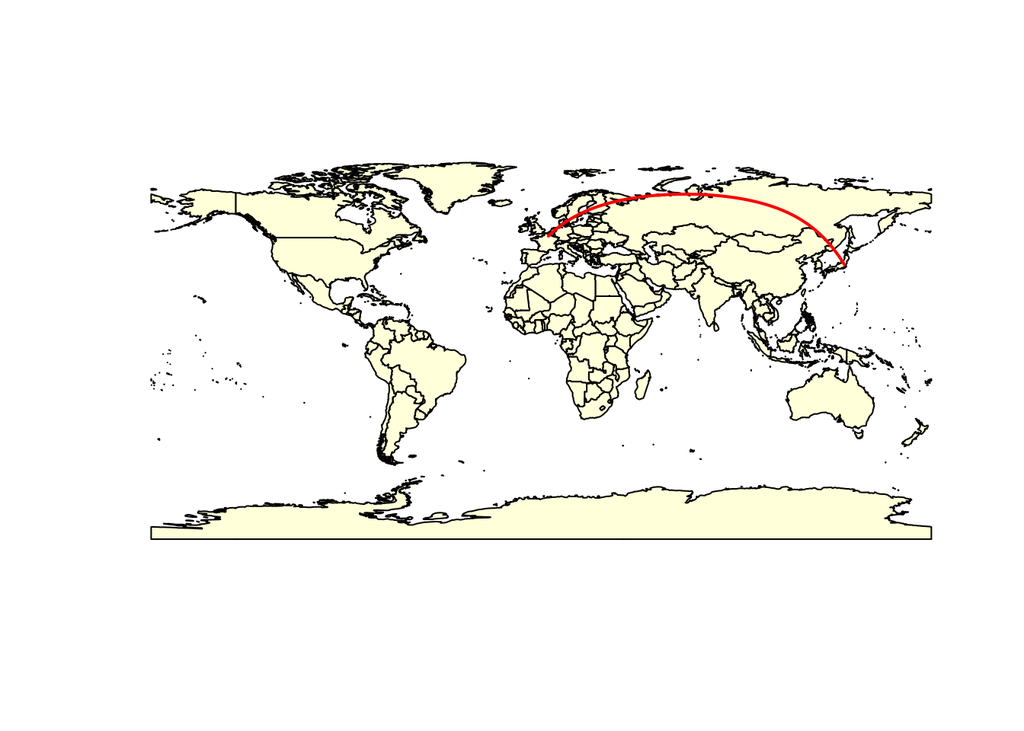

```r
lien <- links %>% filter(Cit_i =="Paris**",
                         Cit_j=="Tokyo")
plot(states$geometry, col="lightyellow")
plot(lien$geometry, col="red",add=T, lwd=2)
```

Essayons ensuite de visualiser tous les liens au départ d’Istanbul :

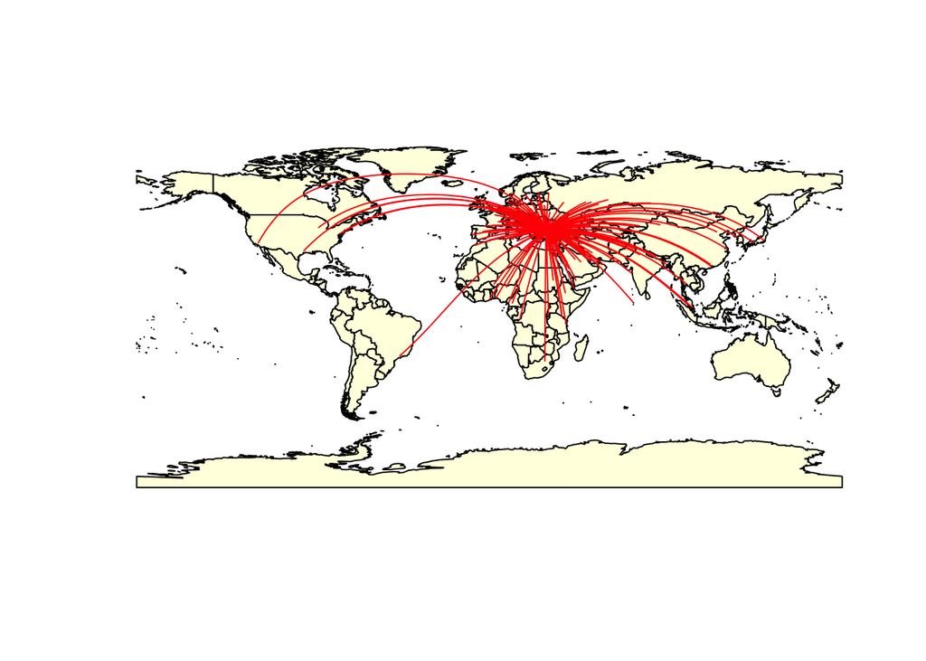

```r
lien <- links %>% filter(Cit_i =="Istanbul")
plot(states$geometry, col="lightyellow")
plot(lien$geometry, col="red",add=T, lwd=1)
```

Ou enfin tous les liens internes à la Chine :

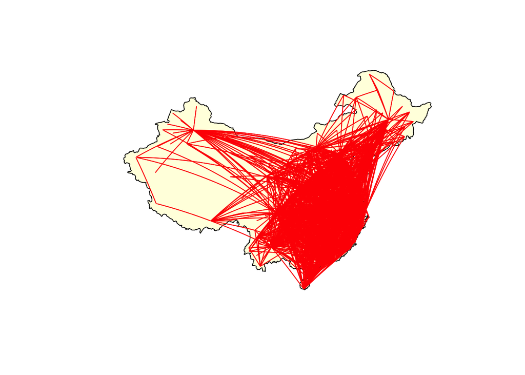

```r
lien <- links %>% filter(Sta_iso3_i =="CHN", Sta_iso3_j=="CHN")
chine<-states %>% filter(ISO3=="CHN")
plot(chine$geometry, col="lightyellow")
plot(lien$geometry, col="red",add=T, lwd=1, alpha=0.3)
```

## 4 Les fichier **states_link.RDS, states_nodes.RDS**

Ce fichier agrège les flux par pays et leur attribue comme référence l’aéroport le plus important du pays en nombre de liaisons. On peut ainsi tracer des liaisons entre pays sous la forme de nombre de liaions directes.

```r
states_nodes <- readRDS("openflight/states_nodes.RDS")
head(states_nodes)
```

```
Simple feature collection with 6 features and 11 fields
Geometry type: POINT
Dimension:     XY
Bounding box:  xmin: -170.71 ymin: -14.331 xmax: 69.2123 ymax: 41.4147
CRS:           NA
         Country ISO3       City ID_ref
1    Afghanistan  AFG      Kabul   2050
2        Albania  ALB     Tirana   1190
3        Algeria  DZA     Algier    210
4 American Samoa  ASM  Pago Pago   1970
5         Angola  AGO     Luanda    951
6       Anguilla  AIA The Valley   2900
                                 Airport_ref VI_tot VN_tot     DI_tot    DN_tot
1         Hamid Karzai International Airport     36     12  51189.875  5618.834
2 Tirana International Airport Mother Teresa     34      0  29872.286     0.000
3                  Houari Boumediene Airport    154    164 265453.079 94561.240
4            Pago Pago International Airport      2      0   8367.527     0.000
5                Quatro de Fevereiro Airport     48     84 229916.114 42407.728
6      Clayton J Lloyd International Airport      8      0   1427.191     0.000
  V_tot      D_tot                 geometry
1    48  56808.709  POINT (69.2123 34.5659)
2    34  29872.286  POINT (19.7206 41.4147)
3   318 360014.319   POINT (3.21541 36.691)
4     2   8367.527  POINT (-170.71 -14.331)
5   132 272323.842 POINT (13.2312 -8.85837)
6     8   1427.191 POINT (-63.0551 18.2048)
```

```r
states_link <- readRDS("openflight/states_link.RDS")
head(states_link)
```

```
Simple feature collection with 6 features and 8 fields
Geometry type: LINESTRING
Dimension:     XY
Bounding box:  xmin: -79.49635 ymin: 4.778999 xmax: 3.62117 ymax: 52.25074
CRS:           NA
  ISO3_j ISO3_i            Country_i Country_j Vij       Dij       Cit_i
1    ABW    ANT Netherlands Antilles     Aruba   2  314.2427 Philipsburg
2    ABW    CAN               Canada     Aruba   1 3576.4425     Toronto
3    ABW    COL             Colombia     Aruba   1  975.0344      Bogota
4    ABW    DOM   Dominican Republic     Aruba   2 1340.6716  Punta Cana
5    ABW    NLD          Netherlands     Aruba   1 7883.0790   Amsterdam
6    ABW    PAN               Panama     Aruba   1 1092.3663 Panama City
       Cit_j                       geometry
1 Oranjestad LINESTRING (-63.17918 17.98...
2 Oranjestad LINESTRING (-79.49635 43.37...
3 Oranjestad LINESTRING (-74.1067 4.7789...
4 Oranjestad LINESTRING (-68.38027 18.50...
5 Oranjestad LINESTRING (3.62117 52.2507...
6 Oranjestad LINESTRING (-79.29175 9.106...
```

On retrouve les indicateurs déjà vus pour les villes en terme de nombres de vols nationaux ou internationaux et de somme des distances. On peut ainsi proposer différentes cartographies de l’intensité des liaisons aériennes entre les pays. Supposons par exemple qu’on veuille visualiser le nombre liaisons directes du Brésil vers d’autres pays.

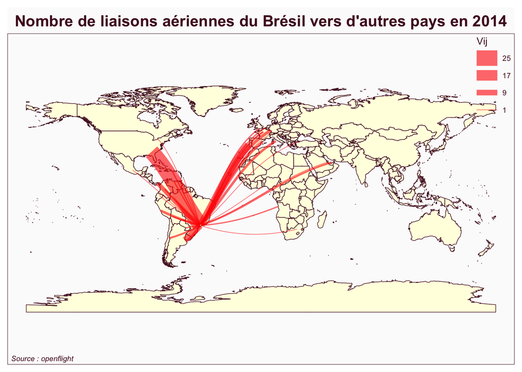

```r
library(mapsf)
maroc_links <- states_link %>% filter(ISO3_i=="BRA")
mf_map(states, type="base", col="lightyellow")
mf_map(maroc_links, type = "prop", var="Vij",col="red",alpha = 0.6)
mf_layout(title = "Nombre de liaisons aériennes du Brésil vers d'autres pays en 2014",
          credits = "Source : openflight",
          scale = F,
          frame = T,
          arrow = F
          )
```